# 汽车之家比亚迪秦口碑数据分析报告

## 目录

- 简介
- 数据收集和整理
  - 数据来源
  - 数据整理
    - 数据评估
    - 数据清理
- 数据分析
- 总结
- 不足与规划

## 简介

汽车之家成立于2005年6月，是全球访问量最大的汽车网站。汽车之家为汽车消费者提供选车、买车、用车、换车等所有环节的全面、准确、快捷的一站式服务。

汽车之家口碑是一个聚焦于欲购车用户和已购车用户，建立评价分享和沟通交流平台，为用户提供了解车主真实用车情况的渠道，帮助用户省时省力了解感兴趣的汽车。截止到2016年底，汽车之家口碑月度活跃用户超过3500万人，在用户规模和流量方面处于行业领导者地位。

本报告旨在对汽车之家比亚迪秦口碑数据进行探索与分析，探讨比亚迪秦这款车型的优势与不足，并对秦插电式混合动力车型和纯电动车型进行对比。为生产商及消费者提供参考。

## 数据收集与整理

### 数据来源

使用八爪鱼爬取汽车之家比亚迪秦口碑数据，数据截止至2018年11月，本数据集不包含比亚迪秦Pro系列各车型。将数据保存至 “汽车之家比亚迪秦口碑.csv” 文件

### 数据整理

#### 一、数据评估

```python
#导入pandas
import pandas as pd
import numpy as np
import re
import matplotlib.pyplot as plt
```

```python
#读取数据
f = open('汽车之家比亚迪秦口碑.csv',encoding = 'gbk')
df = pd.read_csv(f)
f.close()
```

```python
df.head()
```

|  | 购买车型 | 购买地点 | 购买经销商 | 购买时间 | 购买裸车价 | 空间 | 动力 | 操控 | 能耗 | 舒适性 | 外观 | 内饰 | 性价比 | 购车目的1 | 购车目的2 | 购车目的3 | 购车目的4 | 口碑 |
| --- | --- | --- | --- | --- | --- | --- | --- | --- | --- | --- | --- | --- | --- | --- | --- | --- | --- | --- |
| 0 | 秦 2018款 秦EV450 智联尊尚型 | 广州 ? | 广州宝昊城比亚迪 | 2018年11月 | 15.98?万元 补贴后 | 5 | 5 | 5 | 5 | 4 | 5 | 5 | 5 | 上下班 | 购物 | 接送小孩 | 商务接送 | 【最满意的一点】首先就是动力，然后就是外观、空间了。动力很暴躁，一踩就来。还有这个绿牌不限号... |
| 1 | 秦 2018款 秦EV450 智联尊尚型 | 福州 ? | 福州盛世开元比亚迪 | 2018年11月 | 16.15?万元 补贴后 | 4 | 5 | 5 | 5 | 5 | 5 | 5 | 5 | 上下班 | 购物 | 接送小孩 | 自驾游 | 【最满意的一点】续航长！购买新能源纯电车型之前，我一直比较关心的就是这个车子的续航问题。所以... |
| 2 | 秦 2018款 秦EV450 智联尊尚型 | 厦门 ? | 2018年10月 | 16.38?万元 补贴后 | 19.0?千瓦时/百公里3000?公里 | 5 | 5 | 5 | 5 | 5 | 5 | 4 | 5 | 上下班 | 购物 | 接送小孩 | 商务接送 | 【最满意的一点】价格和配置方面都是有一个挺让我满意，外观的设计也是比较在线，内饰没有国产一贯... |
| 3 | 秦 2018款 秦EV450 智联尊尚型 | 泉州 ? | 福建粤迪比亚迪4S店 | 2018年9月 | 16.35?万元 补贴后 | 4 | 5 | 5 | 5 | 5 | 5 | 5 | 5 | 上下班 | 购物 | 接送小孩 | NaN | 【最满意的一点】每个选择新能源无非两个原因，一是指标问题，二是油费问题。我就是后者这种情况，... |
| 4 | 秦 2018款 秦EV450 智联尊尚型 | 福州 ? | 美嘉鑫迪比亚迪 | 2018年11月 | 16.88?万元 补贴后 | 4 | 5 | 4 | 5 | 5 | 5 | 5 | 5 | 上下班 | 购物 | 接送小孩 | 自驾游 | 【最满意的一点】续航长，配置丰富，设计很新颖，无论外观还是内饰的设计我都比较喜欢。【最不满意... |

```python
df.sample(5)
```

|  | 购买车型 | 购买地点 | 购买经销商 | 购买时间 | 购买裸车价 | 空间 | 动力 | 操控 | 能耗 | 舒适性 | 外观 | 内饰 | 性价比 | 购车目的1 | 购车目的2 | 购车目的3 | 购车目的4 | 口碑 |
| --- | --- | --- | --- | --- | --- | --- | --- | --- | --- | --- | --- | --- | --- | --- | --- | --- | --- | --- |
| 573 | 秦 2015款 1.5T 双冠旗舰Plus版 | 上海 ? | 上海华帆旗申汽车 | 2015年6月 | 16.80?万元 | 4 | 5 | 4 | 5 | 4 | 4 | 4 | 4 | 上下班 | NaN | NaN | NaN | 【最满意的一点】基本无油耗 s档动力强【最不满意的一点】电池差 宣传的70km纯电里程从未跑... |
| 496 | 秦 2015款 1.5T 双冠旗舰版 | 内江 ? | 内江川豫汽车 | 2015年9月 | 14.78?万元 | 4 | 5 | 4 | 5 | 5 | 4 | 5 | 5 | 上下班 | 购物 | 接送小孩 | NaN | 【最满意的一点】内饰是同价车中做工最好的，尤其是车内的皮革座椅，非常柔软，有着良好包裹性，是... |
| 951 | 秦 2014款 1.5T 酷黑骑士旗舰型 | 天津 ? | 天津路迪恒泰 | 2014年12月 | 14.33?万元 | 2 | 5 | 5 | 4 | 4 | 4 | 4 | 5 | 上下班 | 自驾游 | NaN | NaN | 【最满意的一点】可纯电行驶，耗电量尚可，里程数稍微少了一点，不过上下班够用了【最不满意的一点... |
| 896 | 秦 2014款 1.5T 酷黑骑士旗舰型 | 西安 ? | 西安新益通 | 2014年11月 | 14.33?万元 | 3 | 5 | 5 | 5 | 5 | 5 | 4 | 4 | 上下班 | 接送小孩 | 自驾游 | 跑长途 | NaN |
| 292 | 秦 2017款 1.5T 尊贵型 | 天津 ? | 天津路迪恒泰 | 2017年9月 | 13.99?万元 | 5 | 5 | 5 | 5 | 5 | 5 | 5 | 5 | 上下班 | 购物 | 接送小孩 | 自驾游 | 【最满意的一点】现在来看，除了头灯，其他都挺好。【最不满意的一点】头灯，卤素的，还而且左右灯... |

```python
#数据概览
df.info()
```

```
<class 'pandas.core.frame.DataFrame'>
RangeIndex: 1233 entries, 0 to 1232
Data columns (total 18 columns):
购买车型     1233 non-null object
购买地点     1233 non-null object
购买经销商    1233 non-null object
购买时间     1233 non-null object
购买裸车价    1221 non-null object
空间       1233 non-null int64
动力       1233 non-null int64
操控       1233 non-null int64
能耗       1233 non-null int64
舒适性      1233 non-null int64
外观       1233 non-null int64
内饰       1233 non-null int64
性价比      1233 non-null int64
购车目的1    1233 non-null object
购车目的2    954 non-null object
购车目的3    650 non-null object
购车目的4    342 non-null object
口碑       908 non-null object
dtypes: int64(8), object(10)
memory usage: 173.5+ KB
```

```python
#查看重复数据
sum(df.duplicated())
```

```
0
```

```python
df.购买车型.value_counts()
```

```
秦                        2015款 1.5T 双冠旗舰Plus版    264
秦                        2014款 1.5T 旗舰型          199
秦                        2014款 1.5T 酷黑骑士旗舰型      196
秦                        2017款 1.5T 尊贵型          147
秦                        2017款 1.5T 秦100          95
秦                        2015款 1.5T 双冠旗舰版         74
秦                        2016款 秦EV300 尊贵型         71
秦                        2018款 秦EV450 智联尊尚型       44
秦                        2016款 秦EV300 尊荣型         41
秦                        2018款 秦EV450 智联锋尚型       23
秦                        2016款 秦EV300 豪华型         18
秦                        2016款 秦EV300 旗舰型         17
秦                        2018款 秦EV450 智联时尚型       15
秦                        2014款 1.5T 酷黑骑士尊贵型       12
秦                        2017款 秦EV300 旗舰型          6
秦                        2017款 秦EV300 尊享型          4
秦                        2014款 1.5T 尊贵型            4
秦                        2017款 秦EV300 精英型          3
Name: 购买车型, dtype: int64
```

```python
df.购买地点.value_counts()
```

```
上海 ?        205
深圳 ?        192
北京 ?        119
西安 ?         80
广州 ?         47
天津 ?         47
南京 ?         33
杭州 ?         29
济南 ?         21
长沙 ?         20
武汉 ?         15
深圳 ?宝安       15
重庆 ?         15
苏州 ?         12
上海 ?浦东新区     11
成都 ?         11
哈尔滨 ?        10
青岛 ?         10
石家庄 ?        10
福州 ?          7
郑州 ?          7
菏泽 ?          6
洛阳 ?          5
南昌 ?          5
临沂 ?          5
金华 ?          5
绍兴 ?          4
衡阳 ?          4
烟台 ?          4
深圳 ?福田        4
           ...
秦皇岛 ?         1
阜阳 ?          1
常德 ?          1
汕头 ?          1
安庆 ?          1
广州 ?黄埔        1
上饶 ?          1
北京 ?大兴        1
株洲 ?          1
辽阳 ?          1
杭州 ?滨江        1
保定 ?          1
鹤壁 ?          1
昌江 ?          1
江门 ?          1
乌鲁木齐 ?        1
廊坊 ?          1
开封 ?          1
营口 ?          1
昆明 ?五华        1
东营 ?          1
商洛 ?          1
保山 ?          1
宜昌 ?          1
定西 ?          1
宿迁 ?          1
三明 ?          1
资阳 ?          1
百色 ?          1
北京 ?房山        1
Name: 购买地点, Length: 194, dtype: int64
```

```python
df.购买时间.value_counts()
```

```
2014年9月                                        38
2014年12月                                       38
2014年11月                                       36
2015年9月                                        32
2016年6月                                        31
2015年6月                                        30
2015年5月                                        29
2015年11月                                       29
2016年7月                                        29
2018年8月                                        28
2018年9月                                        28
2014年10月                                       28
2017年7月                                        27
2017年11月                                       24
2017年12月                                       23
2015年8月                                        22
2017年10月                                       22
2015年7月                                        22
2017年9月                                        20
2014年4月                                        19
2018年1月                                        18
2017年8月                                        18
2017年5月                                        18
2014年3月                                        17
2017年6月                                        17
2018年7月                                        16
2015年10月                                       16
2014年7月                                        16
2016年5月                                        15
2015年12月                                       15
                                               ..
20.28?万元                                        1
20.39?万元                                        1
13.50?万元                                        1
20.52?万元                                        1
17.98?万元                                补贴后     1
21.28?万元                                        1
23.50?万元                                        1
15.78?万元                                        1
14.16?万元                                        1
17.39?万元                                        1
29.98?万元                                        1
14.15?万元                                        1
19.80?万元                                        1
28.88?万元                                        1
25.09?万元                                        1
17.96?万元                                补贴后     1
16.60?万元                                        1
30.52?万元                                        1
28.59?万元                                        1
13.80?万元                                        1
13.30?万元                                补贴后     1
10.53?万元                                补贴后     1
14.43?万元                                        1
19.99?万元                                        1
14.35?万元                                        1
16.99?万元                                        1
26.68?万元                                        1
17.85?万元                                补贴后     1
16.25?万元                                        1
29.89?万元                                        1
Name: 购买时间, Length: 185, dtype: int64
```

```python
df.购买裸车价.value_counts()
```

```
14.33?万元                                       58
13.99?万元                                       57
19.99?万元                                       36
15.00?万元                                       33
14.68?万元                                       28
15.98?万元                                补贴后    24
21.00?万元                                       24
14.30?万元                                       24
14.00?万元                                       21
15.68?万元                                       20
20.98?万元                                       20
15.83?万元                                       19
21.98?万元                                       19
16.00?万元                                       17
13.98?万元                                       16
16.99?万元                                       16
18.59?万元                                       15
20.99?万元                                       15
14.98?万元                                       14
14.70?万元                                       14
14.65?万元                                       13
16.88?万元                                补贴后    12
15.30?万元                                       12
15.99?万元                                补贴后    11
14.80?万元                                       10
13.50?万元                                补贴后     9
26.07?万元                                        9
15.33?万元                                        8
14.60?万元                                        8
15.50?万元                                        8
                                               ..
18.0?千瓦时/百公里500?公里                              1
14.10?万元                                补贴后     1
13.6?千瓦时/百公里906?公里                              1
16.0?千瓦时/百公里13333?公里                            1
15.87?万元                                        1
13.98?万元                                补贴后     1
7.5?升/百公里6?公里                                   1
26.88?万元                                        1
5394?公里                                         1
3.5?升/百公里18.9?千瓦时/百公里15000?公里                   1
13.40?万元                                补贴后     1
20.10?万元                                        1
13.10?万元                                补贴后     1
12.80?万元                                补贴后     1
4.5?升/百公里27780?公里                               1
16.5?千瓦时/百公里4917?公里                             1
2857?公里                                         1
14.0?千瓦时/百公里20000?公里                            1
15.6?千瓦时/百公里4509?公里                             1
18.58?万元                                        1
17.6?千瓦时/百公里4691?公里                             1
15.3?千瓦时/百公里3644?公里                             1
5.1?升/百公里13.0?千瓦时/百公里2000?公里                    1
18.70?万元                                        1
20.0?千瓦时/百公里8842?公里                             1
24.18?万元                                        1
17.77?万元                                        1
395?公里                                          1
12.6?千瓦时/百公里3794?公里                             1
16.35?万元                                补贴后     1
Name: 购买裸车价, Length: 472, dtype: int64
```

#### 评估总结

数据集

- 此数据集包含1233条口碑记录
- 数据集包含购买车型、购买地点、购买经销商、购买时间、购买裸车价、空间、动力、操控、能耗、舒适性、外观、内饰、性价比、购车目的1、购车目的2、购车目的3、购车目的4、口碑字段信息

质量

- 购买车型字段数据存在空字符且字符长度较长，须优化格式
- 购买裸车价、购车目的2、购车目的3、购车目的4、口碑列存在空值
- 购买地点列格式不统一，有些包含区信息
- 购买时间列包含一部分购买裸车价数据，存在部分数据错位
- 购买经销商列包含一部分购买时间数据，存在部分数据错位
- 价格数据不是整形，数据中包含单位“万元”
- 价格数据中包含一些能耗、里程数据
- 经查，比亚迪秦2013年12月上市，数据集中购买时间中存在2011年的数据，为错误数据

#### 二、数据清理

```python
df_clean = df.copy()
```

```python
#购买车型数据优化格式
df_clean.购买车型 = df_clean.购买车型.apply(lambda x:x.split("                        ",1)[1])
```

```python
df_clean.购买车型.value_counts()
```

```
2015款 1.5T 双冠旗舰Plus版    264
2014款 1.5T 旗舰型          199
2014款 1.5T 酷黑骑士旗舰型      196
2017款 1.5T 尊贵型          147
2017款 1.5T 秦100          95
2015款 1.5T 双冠旗舰版         74
2016款 秦EV300 尊贵型         71
2018款 秦EV450 智联尊尚型       44
2016款 秦EV300 尊荣型         41
2018款 秦EV450 智联锋尚型       23
2016款 秦EV300 豪华型         18
2016款 秦EV300 旗舰型         17
2018款 秦EV450 智联时尚型       15
2014款 1.5T 酷黑骑士尊贵型       12
2017款 秦EV300 旗舰型          6
2014款 1.5T 尊贵型            4
2017款 秦EV300 尊享型          4
2017款 秦EV300 精英型          3
Name: 购买车型, dtype: int64
```

```python
#购车地点格式不统一，有些包含区信息
df_clean.购买地点 = df_clean.购买地点.apply(lambda x:x.split()[0])
```

```python
df_clean.购买地点.value_counts()
```

```
上海      219
深圳      215
北京      126
西安       87
天津       51
广州       48
南京       39
杭州       30
济南       23
长沙       20
武汉       18
重庆       15
苏州       13
成都       12
哈尔滨      11
青岛       10
石家庄      10
郑州        7
福州        7
临沂        6
菏泽        6
金华        5
南昌        5
洛阳        5
贵阳        4
东莞        4
合肥        4
绍兴        4
宝鸡        4
厦门        4
       ...
枣庄        1
吕梁        1
太原        1
乐山        1
抚州        1
汕头        1
防城港       1
南充        1
鄂州        1
株洲        1
商洛        1
陇南        1
保定        1
安庆        1
信阳        1
三明        1
辽阳        1
景德镇       1
乌鲁木齐      1
宜昌        1
沧州        1
大理        1
开封        1
嘉兴        1
绥化        1
阜阳        1
衡水        1
漯河        1
伊犁        1
定西        1
Name: 购买地点, Length: 162, dtype: int64
```

```python
#购买时间中包含了一些购买裸车价的数据
for i in range(len(df_clean)):
    if '万元' in df_clean.iloc[i].购买时间:
        df_clean.loc[i,'购买裸车价'] = df_clean.loc[i,'购买时间']
        df_clean.loc[i,'购买时间'] = np.NAN
```

```python
#购买经销商中包含了一些购买时间的数据
for i in range(len(df_clean)):
    if ('年' in df_clean.iloc[i].购买经销商) and ('月' in df_clean.iloc[i].购买经销商):
        df_clean.loc[i,'购买时间'] = df_clean.loc[i,'购买经销商']
        df_clean.loc[i,'购买经销商'] = np.NAN
```

```python
df_clean.购买时间.value_counts()
```

```
2014年12月    46
2014年9月     45
2014年11月    40
2014年10月    38
2015年9月     37
2015年6月     36
2016年6月     35
2016年7月     32
2015年11月    32
2014年3月     31
2017年7月     31
2015年5月     31
2018年8月     29
2018年9月     28
2015年12月    28
2015年7月     28
2014年7月     27
2017年11月    25
2014年5月     25
2014年4月     25
2015年8月     24
2017年12月    24
2017年10月    23
2016年3月     23
2016年2月     22
2014年6月     22
2016年4月     21
2017年9月     21
2015年10月    20
2017年8月     20
            ..
2017年6月     18
2015年2月     17
2018年6月     17
2014年8月     17
2014年1月     17
2018年7月     16
2015年4月     16
2018年5月     15
2016年9月     15
2014年2月     13
2017年3月     11
2016年10月    11
2016年8月     10
2015年3月      9
2018年3月      9
2017年4月      9
2016年11月     8
2018年10月     7
2018年4月      7
2018年11月     5
2017年1月      4
2017年2月      4
2018年2月      4
2016年12月     3
2013年12月     3
2011年11月     1
2010年12月     1
2013年9月      1
2013年5月      1
2013年3月      1
Name: 购买时间, Length: 65, dtype: int64
```

```python
df_clean.购买裸车价.value_counts()
```

```
14.33?万元                                         73
13.99?万元                                         63
15.00?万元                                         45
19.99?万元                                         37
14.68?万元                                         31
14.00?万元                                         31
20.98?万元                                         28
14.30?万元                                         28
15.98?万元                                补贴后      27
15.83?万元                                         26
13.98?万元                                         24
15.68?万元                                         24
21.00?万元                                         24
21.98?万元                                         22
16.00?万元                                         22
16.99?万元                                         17
14.98?万元                                         17
14.65?万元                                         16
14.70?万元                                         16
18.59?万元                                         15
20.99?万元                                         15
15.30?万元                                         14
14.80?万元                                         14
14.50?万元                                         13
16.88?万元                                补贴后      12
15.99?万元                                补贴后      11
13.50?万元                                补贴后      11
14.60?万元                                         11
15.50?万元                                         10
14.40?万元                                          9
                                                 ..
16.25?万元                                          1
18.98?万元                                          1
28.88?万元                                          1
12.89?万元                                          1
26.05?万元                                          1
15.27?万元                                          1
15.82?万元                                          1
26.88?万元                                          1
15.28?万元                                          1
25.59?万元                                          1
17.77?万元                                          1
17.78?万元                                补贴后       1
28.58?万元                                          1
2000.00?万元                                补贴后     1
19.80?万元                                          1
14.10?万元                                补贴后       1
10.53?万元                                补贴后       1
20.36?万元                                          1
25.09?万元                                          1
16.50?万元                                补贴后       1
16.00?万元                                补贴后       1
15.86?万元                                          1
21.90?万元                                          1
13.90?万元                                          1
24.18?万元                                          1
19.80?万元                                补贴后       1
13.70?万元                                          1
21.60?万元                                          1
26.58?万元                                          1
15.63?万元                                          1
Name: 购买裸车价, Length: 296, dtype: int64
```

```python
#价格数据不是整形，数据中包含单位“万元”
df_clean.购买裸车价 = df_clean.购买裸车价.apply(lambda x:x.split("?")[0])
```

```python
df_clean.购买裸车价.value_counts()
```

```
14.33      73
13.99      63
15.00      46
19.99      37
14.00      33
15.98      32
14.68      31
14.30      28
20.98      28
15.68      27
15.83      26
13.98      25
21.00      24
16.00      23
21.98      22
14.98      18
16.99      17
14.65      16
14.70      16
20.99      15
13.50      15
18.59      15
14.80      15
15.30      14
14.50      13
16.88      12
14.88      11
15.99      11
14.60      11
15.50      10
           ..
18.96       1
24.85       1
16.48       1
32.36       1
13.72       1
13.05       1
22.15       1
15.69       1
14.05       1
24.18       1
28.59       1
20.81       1
18.88       1
15.87       1
2000.00     1
18.70       1
21.68       1
20.88       1
14.97       1
29.89       1
30.52       1
26.05       1
17.88       1
12.85       1
12.89       1
25.59       1
27.07       1
20.82       1
26.58       1
18.98       1
Name: 购买裸车价, Length: 254, dtype: int64
```

```python
#删除购买经销商列
df_clean.drop(['购买经销商'],axis = 1,inplace = True)
```

```python
#更改字段名。购买裸车价加入单位'（万元）'
df_clean.columns = ['购买车型', '购买地点', '购买时间', '购买裸车价（万元）', '空间', '动力', '操控', '能耗', '舒适性', '外观',
       '内饰', '性价比', '购车目的1', '购车目的2', '购车目的3','购车目的4','口碑']
```

```python
df_clean.columns
```

```
Index(['购买车型', '购买地点', '购买时间', '购买裸车价（万元）', '空间', '动力', '操控', '能耗', '舒适性',
       '外观', '内饰', '性价比', '购车目的1', '购车目的2', '购车目的3', '购车目的4', '口碑'],
      dtype='object')
```

```python
#更改购买裸车价数据类型
df_clean['购买裸车价（万元）']=pd.to_numeric(df_clean['购买裸车价（万元）'])
```

```python
df_clean['购买裸车价（万元）'].dtype
```

```
dtype('float64')
```

```python
df_clean.describe()
```

|  | 购买裸车价（万元） | 空间 | 动力 | 操控 | 能耗 | 舒适性 | 外观 | 内饰 | 性价比 |
| --- | --- | --- | --- | --- | --- | --- | --- | --- | --- |
| count | 1233.000000 | 1233.000000 | 1233.000000 | 1233.000000 | 1233.000000 | 1233.000000 | 1233.000000 | 1233.000000 | 1233.000000 |
| mean | 18.249165 | 4.175182 | 4.901054 | 4.491484 | 4.663423 | 4.358475 | 4.450933 | 4.336577 | 4.679643 |
| std | 56.590829 | 0.715188 | 0.358035 | 0.702593 | 0.692797 | 0.729456 | 0.749069 | 0.772561 | 0.662332 |
| min | 10.530000 | 1.000000 | 1.000000 | 1.000000 | 1.000000 | 1.000000 | 1.000000 | 1.000000 | 1.000000 |
| 25% | 14.330000 | 4.000000 | 5.000000 | 4.000000 | 5.000000 | 4.000000 | 4.000000 | 4.000000 | 5.000000 |
| 50% | 15.300000 | 4.000000 | 5.000000 | 5.000000 | 5.000000 | 4.000000 | 5.000000 | 4.000000 | 5.000000 |
| 75% | 17.800000 | 5.000000 | 5.000000 | 5.000000 | 5.000000 | 5.000000 | 5.000000 | 5.000000 | 5.000000 |
| max | 2000.000000 | 5.000000 | 5.000000 | 5.000000 | 5.000000 | 5.000000 | 5.000000 | 5.000000 | 5.000000 |

购买裸车价最大值为2000万元，为异常值

```python
df_clean[df_clean['购买裸车价（万元）']==2000.00]
```

|  | 购买车型 | 购买地点 | 购买时间 | 购买裸车价（万元） | 空间 | 动力 | 操控 | 能耗 | 舒适性 | 外观 | 内饰 | 性价比 | 购车目的1 | 购车目的2 | 购车目的3 | 购车目的4 | 口碑 |
| --- | --- | --- | --- | --- | --- | --- | --- | --- | --- | --- | --- | --- | --- | --- | --- | --- | --- |
| 670 | 2015款 1.5T 双冠旗舰Plus版 | 西安 | 2015年7月 | 2000.0 | 5 | 5 | 5 | 5 | 5 | 5 | 5 | 5 | 上下班 | NaN | NaN | NaN | 【最满意的一点】动力充足，内饰大气，有60万的车的配置，一个字，酷【最不满意的一点】现在还没... |

```python
df_clean.drop([670],inplace=True)
```

```python
df_clean[df_clean['购买裸车价（万元）']==2000.00]
```

|  | 购买车型 | 购买地点 | 购买时间 | 购买裸车价（万元） | 空间 | 动力 | 操控 | 能耗 | 舒适性 | 外观 | 内饰 | 性价比 | 购车目的1 | 购车目的2 | 购车目的3 | 购车目的4 | 口碑 |
| --- | --- | --- | --- | --- | --- | --- | --- | --- | --- | --- | --- | --- | --- | --- | --- | --- | --- |

```python
#剔除购买时间为2013年12月之前的数据
df_clean = df_clean[df_clean['购买时间']>= '2013年12月']
```

```python
df_clean[df_clean['购买时间']< '2013年12月']
```

|  | 购买车型 | 购买地点 | 购买时间 | 购买裸车价（万元） | 空间 | 动力 | 操控 | 能耗 | 舒适性 | 外观 | 内饰 | 性价比 | 购车目的1 | 购车目的2 | 购车目的3 | 购车目的4 | 口碑 |
| --- | --- | --- | --- | --- | --- | --- | --- | --- | --- | --- | --- | --- | --- | --- | --- | --- | --- |

```python
#reset index
df_clean = df_clean.reset_index(drop=True)
```

```python
df_clean.info()
```

```
<class 'pandas.core.frame.DataFrame'>
RangeIndex: 1230 entries, 0 to 1229
Data columns (total 17 columns):
购买车型         1230 non-null object
购买地点         1230 non-null object
购买时间         1230 non-null object
购买裸车价（万元）    1230 non-null float64
空间           1230 non-null int64
动力           1230 non-null int64
操控           1230 non-null int64
能耗           1230 non-null int64
舒适性          1230 non-null int64
外观           1230 non-null int64
内饰           1230 non-null int64
性价比          1230 non-null int64
购车目的1        1230 non-null object
购车目的2        953 non-null object
购车目的3        649 non-null object
购车目的4        341 non-null object
口碑           905 non-null object
dtypes: float64(1), int64(8), object(8)
memory usage: 163.4+ KB
```

```python
df_clean.head(5)
```

|  | 购买车型 | 购买地点 | 购买时间 | 购买裸车价（万元） | 空间 | 动力 | 操控 | 能耗 | 舒适性 | 外观 | 内饰 | 性价比 | 购车目的1 | 购车目的2 | 购车目的3 | 购车目的4 | 口碑 |
| --- | --- | --- | --- | --- | --- | --- | --- | --- | --- | --- | --- | --- | --- | --- | --- | --- | --- |
| 0 | 2018款 秦EV450 智联尊尚型 | 广州 | 2018年11月 | 15.98 | 5 | 5 | 5 | 5 | 4 | 5 | 5 | 5 | 上下班 | 购物 | 接送小孩 | 商务接送 | 【最满意的一点】首先就是动力，然后就是外观、空间了。动力很暴躁，一踩就来。还有这个绿牌不限号... |
| 1 | 2018款 秦EV450 智联尊尚型 | 福州 | 2018年11月 | 16.15 | 4 | 5 | 5 | 5 | 5 | 5 | 5 | 5 | 上下班 | 购物 | 接送小孩 | 自驾游 | 【最满意的一点】续航长！购买新能源纯电车型之前，我一直比较关心的就是这个车子的续航问题。所以... |
| 2 | 2018款 秦EV450 智联尊尚型 | 厦门 | 2018年10月 | 16.38 | 5 | 5 | 5 | 5 | 5 | 5 | 4 | 5 | 上下班 | 购物 | 接送小孩 | 商务接送 | 【最满意的一点】价格和配置方面都是有一个挺让我满意，外观的设计也是比较在线，内饰没有国产一贯... |
| 3 | 2018款 秦EV450 智联尊尚型 | 泉州 | 2018年9月 | 16.35 | 4 | 5 | 5 | 5 | 5 | 5 | 5 | 5 | 上下班 | 购物 | 接送小孩 | NaN | 【最满意的一点】每个选择新能源无非两个原因，一是指标问题，二是油费问题。我就是后者这种情况，... |
| 4 | 2018款 秦EV450 智联尊尚型 | 福州 | 2018年11月 | 16.88 | 4 | 5 | 4 | 5 | 5 | 5 | 5 | 5 | 上下班 | 购物 | 接送小孩 | 自驾游 | 【最满意的一点】续航长，配置丰富，设计很新颖，无论外观还是内饰的设计我都比较喜欢。【最不满意... |

- 购车目的和口碑列的空值不影响后面的分析，因此不作处理。数据清理至此已完成。
- 为了便于后面的分析，我们依据汽车动力类型加入‘汽车类型’列，分为纯电动车型和插电式混合动力车型两种；并从口碑数据提取出‘最满意的一点’列和‘最不满意的一点’列。

```python
#加入汽车类型列
list_EV = ['2016款 秦EV300 尊贵型','2018款 秦EV450 智联尊尚型','2016款 秦EV300 尊荣型','2018款 秦EV450 智联锋尚型',
            '2016款 秦EV300 豪华型','2016款 秦EV300 旗舰型','2018款 秦EV450 智联时尚型','2017款 秦EV300 旗舰型',
           '2017款 秦EV300 尊享型','2017款 秦EV300 精英型']
```

```python
#拆分口碑数据为'最满意的一点'列和'最不满意的一点'列
for i in range(len(df_clean)):
    if df_clean.loc[i,'购买车型'] in list_EV:
        df_clean.loc[i,'汽车类型'] = "EV"
    else:
        df_clean.loc[i,'汽车类型'] = "DM"
```

```python
#口碑数据提取出‘最满意的一点’列和‘最不满意的一点’列。
satisfaction = df_clean.口碑.str.extract('(?<=【最满意的一点】)(.+?)(?=【最不满意的一点】)',expand=True)
dissatisfaction = df_clean.口碑.str.extract('(?<=【最不满意的一点】)(.+?)(?=【空间】)',expand=True)
```

```python
for i in range(len(df_clean)):
    df_clean.loc[i,'最满意的一点'] = satisfaction.loc[i,0]
    df_clean.loc[i,'最不满意的一点'] = dissatisfaction.loc[i,0]
```

```python
#删除口碑列
df_clean.drop(['口碑'],axis = 1,inplace = True)
```

```python
df_clean.info()
```

```
<class 'pandas.core.frame.DataFrame'>
RangeIndex: 1230 entries, 0 to 1229
Data columns (total 19 columns):
购买车型         1230 non-null object
购买地点         1230 non-null object
购买时间         1230 non-null object
购买裸车价（万元）    1230 non-null float64
空间           1230 non-null int64
动力           1230 non-null int64
操控           1230 non-null int64
能耗           1230 non-null int64
舒适性          1230 non-null int64
外观           1230 non-null int64
内饰           1230 non-null int64
性价比          1230 non-null int64
购车目的1        1230 non-null object
购车目的2        953 non-null object
购车目的3        649 non-null object
购车目的4        341 non-null object
汽车类型         1230 non-null object
最满意的一点       884 non-null object
最不满意的一点      823 non-null object
dtypes: float64(1), int64(8), object(10)
memory usage: 182.7+ KB
```

```python
df_clean.head(5)
```

|  | 购买车型 | 购买地点 | 购买时间 | 购买裸车价（万元） | 空间 | 动力 | 操控 | 能耗 | 舒适性 | 外观 | 内饰 | 性价比 | 购车目的1 | 购车目的2 | 购车目的3 | 购车目的4 | 汽车类型 | 最满意的一点 | 最不满意的一点 |
| --- | --- | --- | --- | --- | --- | --- | --- | --- | --- | --- | --- | --- | --- | --- | --- | --- | --- | --- | --- |
| 0 | 2018款 秦EV450 智联尊尚型 | 广州 | 2018年11月 | 15.98 | 5 | 5 | 5 | 5 | 4 | 5 | 5 | 5 | 上下班 | 购物 | 接送小孩 | 商务接送 | EV | 首先就是动力，然后就是外观、空间了。动力很暴躁，一踩就来。还有这个绿牌不限号，省去了出门还要... | 提车的时间太久了，一个多月才提上这个车。 |
| 1 | 2018款 秦EV450 智联尊尚型 | 福州 | 2018年11月 | 16.15 | 4 | 5 | 5 | 5 | 5 | 5 | 5 | 5 | 上下班 | 购物 | 接送小孩 | 自驾游 | EV | 续航长！购买新能源纯电车型之前，我一直比较关心的就是这个车子的续航问题。所以决心买新能源车型... | 为什么现在新能源这么流行呢，优点实在太多。好的地方可以遮掉那些不好的地方带来的影响，所以我目... |
| 2 | 2018款 秦EV450 智联尊尚型 | 厦门 | 2018年10月 | 16.38 | 5 | 5 | 5 | 5 | 5 | 5 | 4 | 5 | 上下班 | 购物 | 接送小孩 | 商务接送 | EV | 价格和配置方面都是有一个挺让我满意，外观的设计也是比较在线，内饰没有国产一贯那样老旧，看着挺... | 要说个不喜欢的地方就是新能源的普及还是没有大规模来吧，这让我们这属于先吃螃蟹的人不是那么方便... |
| 3 | 2018款 秦EV450 智联尊尚型 | 泉州 | 2018年9月 | 16.35 | 4 | 5 | 5 | 5 | 5 | 5 | 5 | 5 | 上下班 | 购物 | 接送小孩 | NaN | EV | 每个选择新能源无非两个原因，一是指标问题，二是油费问题。我就是后者这种情况，自己家里有停车位... | 挑个不满意的估计就是后备箱的空间了，没我想象中大，要是再大一点就好了，当初看车试驾的时候感觉... |
| 4 | 2018款 秦EV450 智联尊尚型 | 福州 | 2018年11月 | 16.88 | 4 | 5 | 4 | 5 | 5 | 5 | 5 | 5 | 上下班 | 购物 | 接送小孩 | 自驾游 | EV | 续航长，配置丰富，设计很新颖，无论外观还是内饰的设计我都比较喜欢。 | 没有led大灯，虽然尾灯还有日行车都用上了led，但是如果大灯也是led就更好了 |

经整理后此数据集包含1230条口碑记录，数据集包含购买车型、购买地点、购买时间、购买裸车价（万元）、空间、动力、操控、能耗、舒适性、外观、内饰、性价比、购车目的1、购车目的2、购车目的3、购车目的4、最满意的一点，最不满意的一点字段信息

```python
#将整理后数据保存至"汽车之家比亚迪秦口碑_整理.csv"
df_clean.to_csv("汽车之家比亚迪秦口碑_整理.csv",encoding='gbk',index=0)
```

## 数据分析

```python
#导入所需要的包
import pandas as pd
import numpy as np
import re
import matplotlib.pyplot as plt
from pyecharts import Radar
from pyecharts import WordCloud
from pyecharts import Pie
from PIL import Image
import jieba
#网络环境html显示图片时
#from pyecharts import online
#pyecharts图片格式设置为svg
#from pyecharts import configure
```

```python
# 用来正常显示中文标签
plt.rcParams['font.sans-serif']=['SimHei']
# 用来正常显示负号
plt.rcParams['axes.unicode_minus']=False
#网络环境html显示图片时
#online()
#pyecharts图片格式设置为svg
#configure(output_image='svg')#pyecharts图片格式设置为svg
```

```python
#读取数据
f = open('汽车之家比亚迪秦口碑_整理.csv',encoding = 'gbk')
df = pd.read_csv(f)
f.close()
```

```python
df.head()
```

|  | 购买车型 | 购买地点 | 购买时间 | 购买裸车价（万元） | 空间 | 动力 | 操控 | 能耗 | 舒适性 | 外观 | 内饰 | 性价比 | 购车目的1 | 购车目的2 | 购车目的3 | 购车目的4 | 汽车类型 | 最满意的一点 | 最不满意的一点 |
| --- | --- | --- | --- | --- | --- | --- | --- | --- | --- | --- | --- | --- | --- | --- | --- | --- | --- | --- | --- |
| 0 | 2018款 秦EV450 智联尊尚型 | 广州 | 2018年11月 | 15.98 | 5 | 5 | 5 | 5 | 4 | 5 | 5 | 5 | 上下班 | 购物 | 接送小孩 | 商务接送 | EV | 首先就是动力，然后就是外观、空间了。动力很暴躁，一踩就来。还有这个绿牌不限号，省去了出门还要... | 提车的时间太久了，一个多月才提上这个车。 |
| 1 | 2018款 秦EV450 智联尊尚型 | 福州 | 2018年11月 | 16.15 | 4 | 5 | 5 | 5 | 5 | 5 | 5 | 5 | 上下班 | 购物 | 接送小孩 | 自驾游 | EV | 续航长！购买新能源纯电车型之前，我一直比较关心的就是这个车子的续航问题。所以决心买新能源车型... | 为什么现在新能源这么流行呢，优点实在太多。好的地方可以遮掉那些不好的地方带来的影响，所以我目... |
| 2 | 2018款 秦EV450 智联尊尚型 | 厦门 | 2018年10月 | 16.38 | 5 | 5 | 5 | 5 | 5 | 5 | 4 | 5 | 上下班 | 购物 | 接送小孩 | 商务接送 | EV | 价格和配置方面都是有一个挺让我满意，外观的设计也是比较在线，内饰没有国产一贯那样老旧，看着挺... | 要说个不喜欢的地方就是新能源的普及还是没有大规模来吧，这让我们这属于先吃螃蟹的人不是那么方便... |
| 3 | 2018款 秦EV450 智联尊尚型 | 泉州 | 2018年9月 | 16.35 | 4 | 5 | 5 | 5 | 5 | 5 | 5 | 5 | 上下班 | 购物 | 接送小孩 | NaN | EV | 每个选择新能源无非两个原因，一是指标问题，二是油费问题。我就是后者这种情况，自己家里有停车位... | 挑个不满意的估计就是后备箱的空间了，没我想象中大，要是再大一点就好了，当初看车试驾的时候感觉... |
| 4 | 2018款 秦EV450 智联尊尚型 | 福州 | 2018年11月 | 16.88 | 4 | 5 | 4 | 5 | 5 | 5 | 5 | 5 | 上下班 | 购物 | 接送小孩 | 自驾游 | EV | 续航长，配置丰富，设计很新颖，无论外观还是内饰的设计我都比较喜欢。 | 没有led大灯，虽然尾灯还有日行车都用上了led，但是如果大灯也是led就更好了 |

1.各车型数量

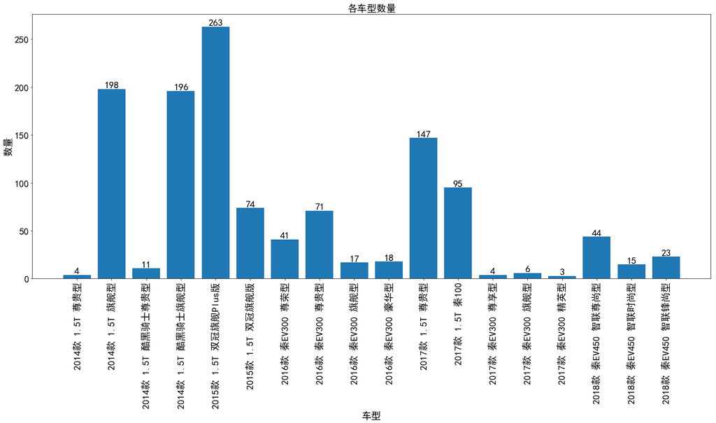

```python
plt.figure(figsize = (25,10))
plt.bar(df.购买车型.value_counts().index,df.购买车型.value_counts())
#添加数据标签
for a,b in zip(df.购买车型.value_counts().index,df.购买车型.value_counts()):
    plt.text(a, b+0.05,b, ha='center', va= 'bottom',fontsize=20)
plt.title("各车型数量",size = 20)
plt.xlabel("车型",size = 20)
plt.ylabel("数量",size = 20)
plt.xticks(rotation=90,size = 20)
plt.yticks(size = 20);
```

2.各城市数量

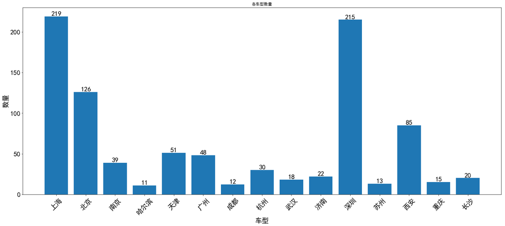

```python
plt.figure(figsize = (25,10))
plt.bar(df.购买地点.value_counts().index[:15],df.购买地点.value_counts()[:15])
#添加数据标签
for a,b in zip(df.购买地点.value_counts().index[:15],df.购买地点.value_counts()[:15]):
    plt.text(a, b+0.05,b, ha='center', va= 'bottom',fontsize=20)
plt.title("各车型数量")
plt.xlabel("车型",size = 20)
plt.ylabel("数量",size = 20)
plt.xticks(rotation=45,size = 20)
plt.yticks(size = 20);
```

此口碑数据集购买地点数量前三的城市为上海、深圳和北京。

3.时间分布

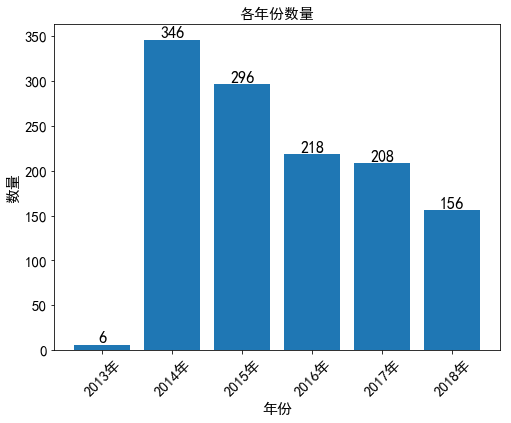

```python
for i in range(len(df)):
    df.loc[i,'购买年份'] = df.loc[i,'购买时间'][0:5]

plt.figure(figsize = (8,6))
plt.bar(df.购买年份.value_counts().index,df.购买年份.value_counts())
#添加数据标签
for a,b in zip(df.购买年份.value_counts().index,df.购买年份.value_counts()):
    plt.text(a, b+0.05,b, ha='center', va= 'bottom',fontsize=16)
plt.title("各年份数量",size = 15)
plt.xlabel("年份",size = 15)
plt.ylabel("数量",size = 15)
plt.xticks(rotation=45,size = 15)
plt.yticks(size = 15);
```

此口碑数据集车辆的购买时间自2014年至2017年逐年递减。

4.各车型车价

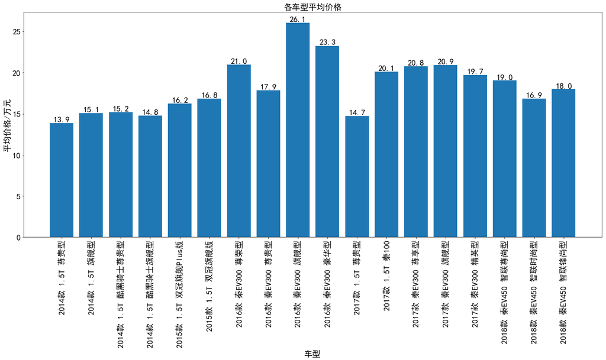

```python
df_price = df.groupby([df['购买车型']])['购买裸车价（万元）'].mean()

plt.figure(figsize = (25,10))
plt.bar(df_price.index,df_price)
#添加数据标签
for a,b in zip(df_price.index,df_price):
    plt.text(a, b+0.05,round(b,1), ha='center', va= 'bottom',fontsize=20)
plt.title("各车型平均价格",size = 20)
plt.xlabel("车型",size = 20)
plt.ylabel("平均价格/万元",size = 20)
plt.xticks(rotation=90,size = 20)
plt.yticks(size = 20);
```

此口碑数据集中售价前三的车型为 2016款 秦EV300 旗舰型，2016款 秦EV300 豪华型 和 2016款 秦EV300 尊荣型，皆为2016款秦EV300系列车型，且为比亚迪秦家族首款纯电车型，拥有比较高价格。纯电动车型价格普遍高于插电式混合动力车型。

5.各车型综合评分

```python
#计算综合评分
for i in range(len(df)):
    df.loc[i,'综合评分'] = sum([df.loc[i,j] for j in ['空间', '动力', '操控', '能耗', '舒适性',
       '外观', '内饰', '性价比']])/8
```

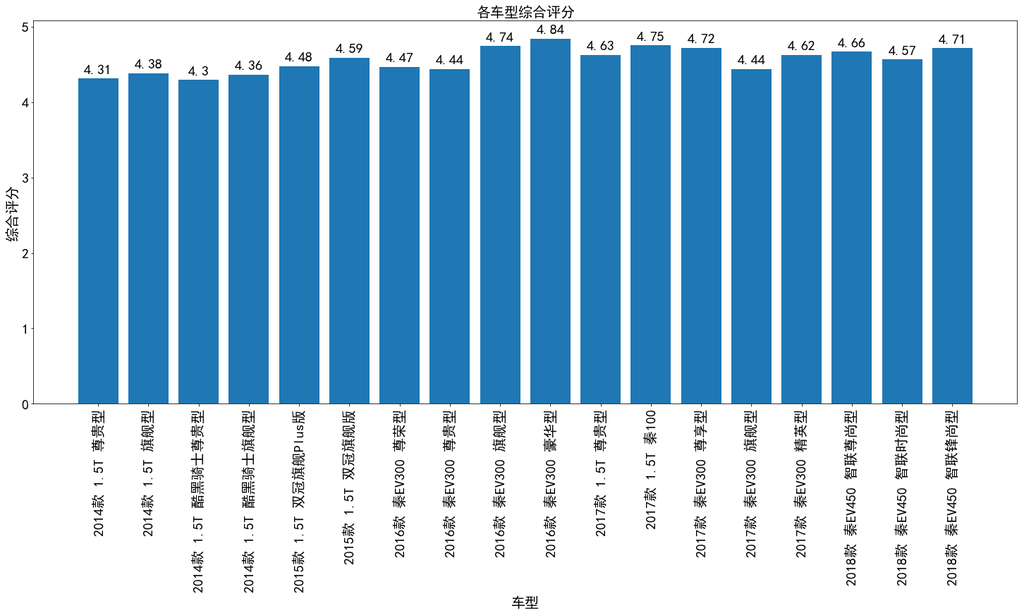

```python
df_score = df.groupby([df['购买车型']])['综合评分'].mean()

plt.figure(figsize = (25,10))
plt.bar(df_score.index,df_score)
#添加数据标签
for a,b in zip(df_score.index,df_score):
    plt.text(a, b+0.05,round(b,2), ha='center', va= 'bottom',fontsize=20)
plt.title("各车型综合评分",size = 20)
plt.xlabel("车型",size = 20)
plt.ylabel("综合评分",size = 20)
plt.xticks(rotation=90,size = 20)
plt.yticks(size = 20);
```

6.不同评分标准下各车型的表现

```python
def score_of_aspect(aspect):
    df_score = df.groupby([df['购买车型']])[aspect].mean()
    plt.figure(figsize = (25,10))
    plt.bar(df_score.index,df_score)
    #添加数据标签
    for a,b in zip(df_score.index,df_score):
        plt.text(a, b+0.05,round(b,2), ha='center', va= 'bottom',fontsize=20)
    plt.title("不同车型"+aspect+"评分",size = 20)
    plt.xlabel("车型",size = 20)
    plt.ylabel("评分",size = 20)
    plt.xticks(rotation=90,size = 20)
    plt.yticks(size = 20);
```

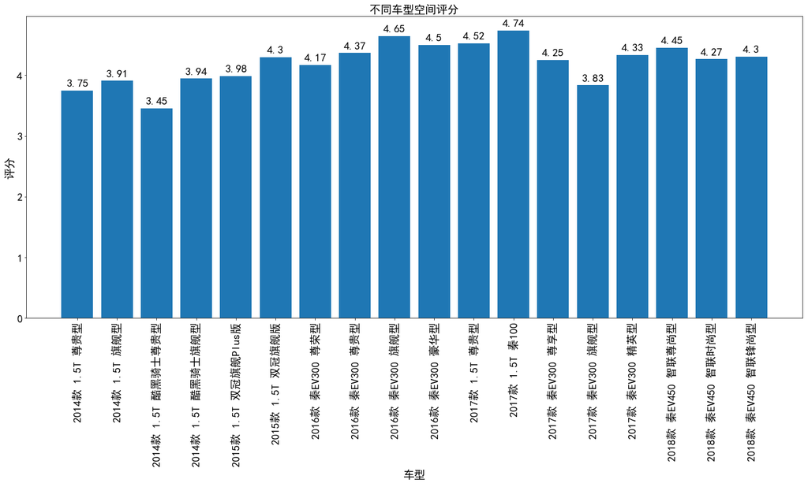

```python
score_of_aspect('空间')
```

各车型空间评分差距略明显，其中2017款 1.5T 秦100 拥有最高的空间评分4.74分，而2014款 1.5T酷黑骑士尊贵型的空间评分仅为3.45分，为最低空间评分；

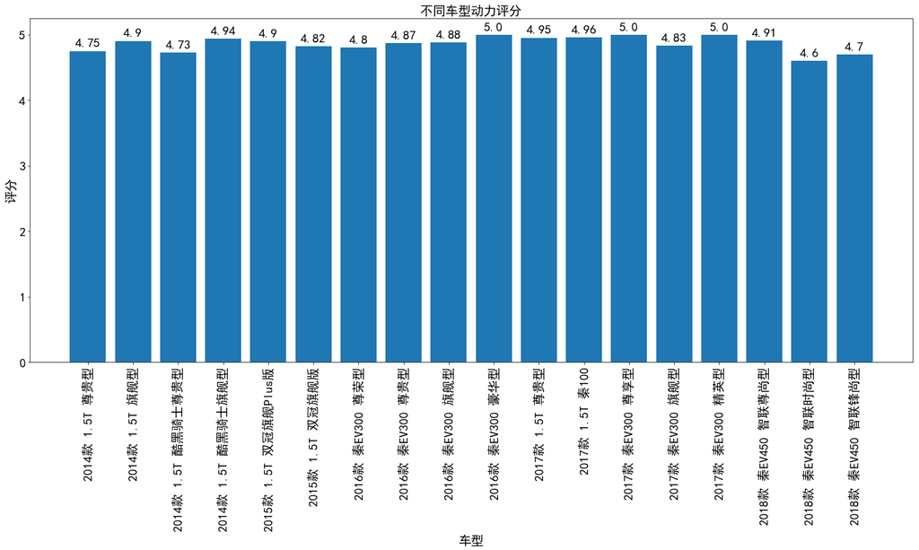

```python
score_of_aspect('动力')
```

动力方面各车型无较大差异，总体评分较高；

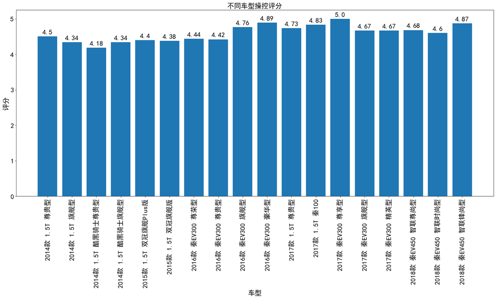

```python
score_of_aspect('操控')
```

各车型操控评分普遍较为优秀，且随着车型的更迭呈现上升趋势；

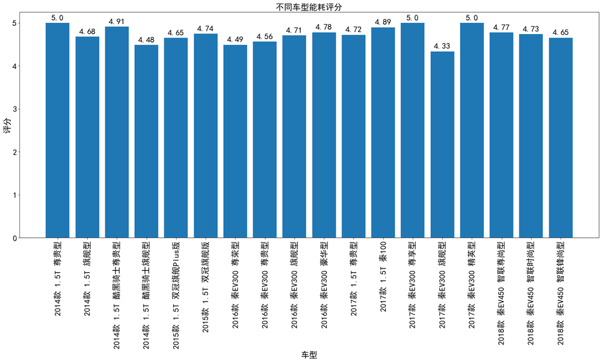

```python
score_of_aspect('能耗')
```

各车型能耗评分总体较为良好，其中2017款 秦EV300 旗舰型的能耗评分最低，为4.33分；

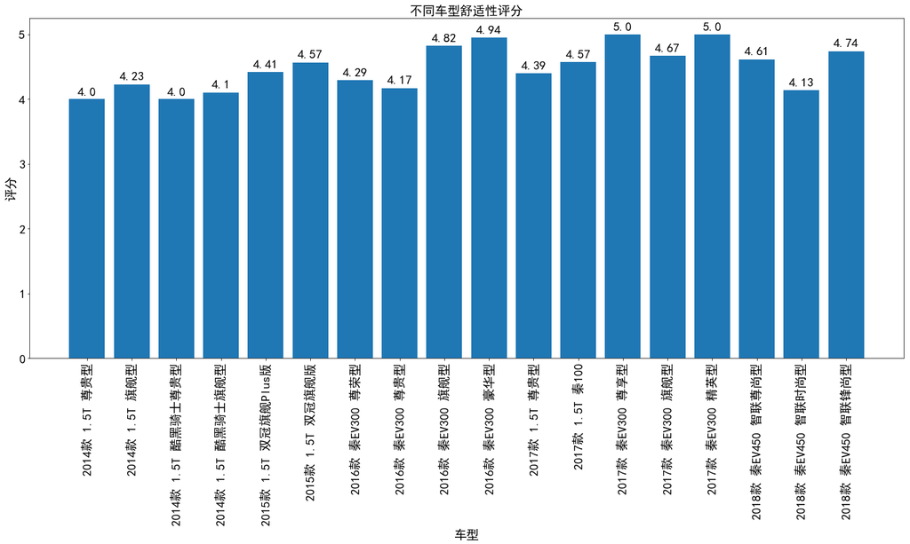

```python
score_of_aspect('舒适性')
```

各车型舒适性评分差距较明显，评分区间为4.0分-5.0分,但是评分随着车型的更迭呈现上升趋势；

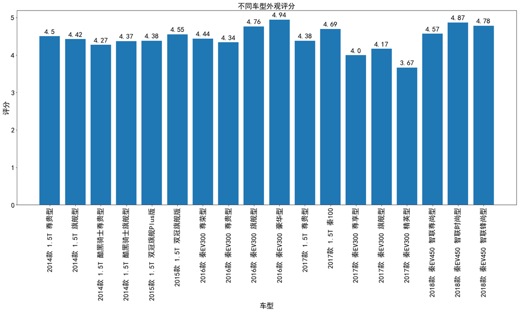

```python
score_of_aspect('外观')
```

外观评分总体较为良好，但是2017款秦EV300系列车型外观评分较其他车型略低；

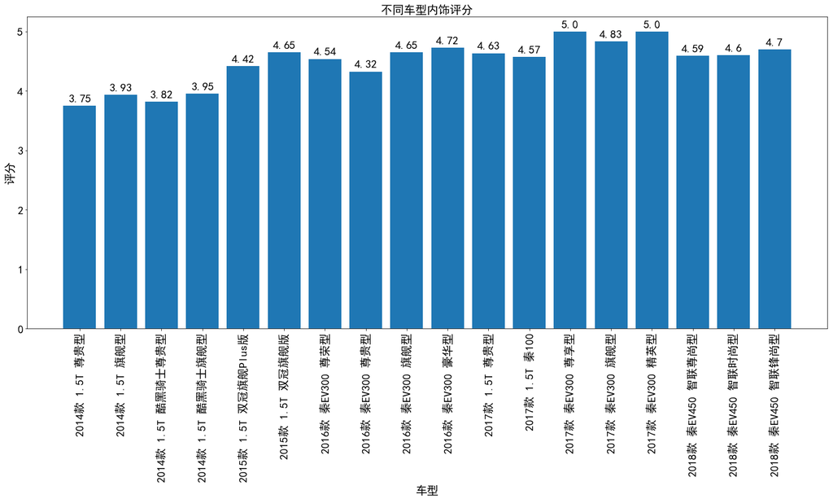

```python
score_of_aspect('内饰')
```

各车型内饰评分差距较明显，评分区间为3.75分-5.0分,但是评分随着车型的更迭呈现上升趋势；

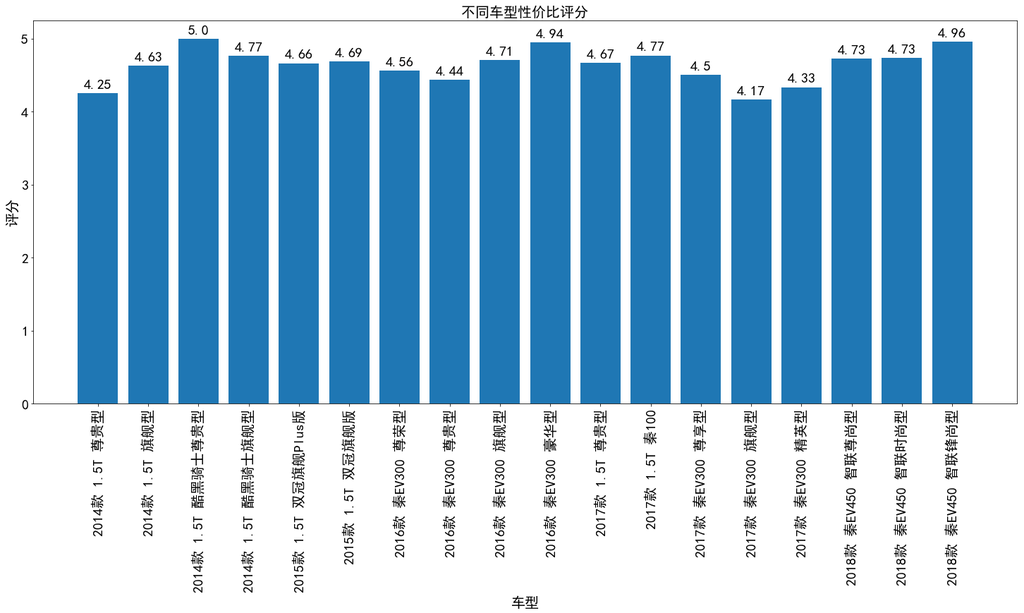

```python
score_of_aspect('性价比')
```

各车型性价比评分区间为4.17分-5分，性价比评分前三的车型为 2014 款1.5T 酷黑骑士尊贵型，2018款 秦EV450 智联锋尚型和2016款秦EV300豪华型。性价比评分最低的车型为2017款 秦EV300 旗舰型，为4.17分；

7.纯电动车型和插电式混合动力车型对比

7.1 数量对比

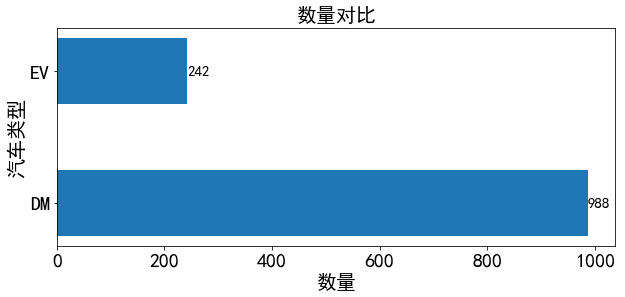

```python
df_num = df['汽车类型'].groupby(df['汽车类型']).count()
plt.figure(figsize = (10,4))
b = plt.barh(df_num.index,df_num,height = 0.5)
for rect in b:
    w=rect.get_width()
    plt.text(w,rect.get_y()+rect.get_height()/2,round(w,1),ha='left',va='center',size = 15)
plt.title("数量对比",size = 20)
plt.xlabel("数量",size = 20)
plt.ylabel("汽车类型",size = 20)
plt.xticks(size = 20)
plt.yticks(size = 20);
```

此口碑数据集包含插电式混合动力车型的数量为988辆，纯电动车型为242辆，插电混合式动力动力车型为主要车型。

7.2 价格对比

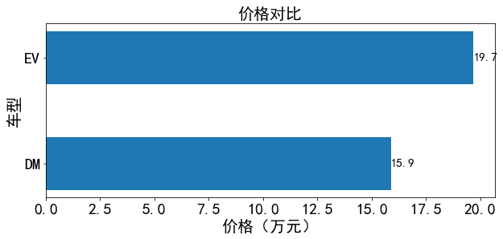

```python
df_score = df['购买裸车价（万元）'].groupby(df['汽车类型']).mean()
plt.figure(figsize = (10,4))
b = plt.barh(df_score.index,df_score,height = 0.5)
for rect in b:
    w=rect.get_width()
    plt.text(w,rect.get_y()+rect.get_height()/2,round(w,1),ha='left',va='center',size = 15)
plt.title("价格对比",size = 20)
plt.xlabel("价格（万元）",size = 20)
plt.ylabel("车型",size = 20)
plt.xticks(size = 20)
plt.yticks(size = 20);
```

纯电动车型平均售价为19.7万元，插电式混合动力车型平均售价为15.9万元，纯电动车型拥有更高的售价。

7.3 综合评分对比

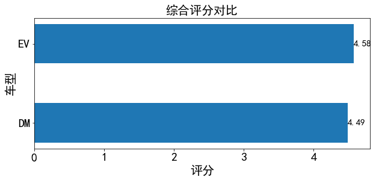

```python
df_score = df['综合评分'].groupby(df['汽车类型']).mean()
plt.figure(figsize = (10,4))
b = plt.barh(df_score.index,df_score,height = 0.5)
for rect in b:
    w=rect.get_width()
    plt.text(w,rect.get_y()+rect.get_height()/2,round(w,2),ha='left',va='center',size = 15)
plt.title("综合评分对比",size = 20)
plt.xlabel("评分",size = 20)
plt.ylabel("车型",size = 20)
plt.xticks(size = 20)
plt.yticks(size = 20);
```

纯电动车型综合评分为4.58分，插电式混合车型综合评分为4.49分，纯电动车型评分略高。

7.4 各项评分对比

7.4.1 纯电动车型

```python
list_aspect = ["空间","动力","操控","能耗","舒适性","外观","内饰","性价比"]
schema = [ ("空间",5), ("动力",5), ("操控",5),("能耗",5),("舒适性",5), ("外观",5),("内饰",5), ("性价比",5)]
df_EV = df[df['汽车类型'] == 'EV']
df_DM = df[df['汽车类型'] == 'DM']
v1= []
v2= []
```

```
phantomjs version: 2.1.1

Generating file ...
File saved in C:\Users\Administrator\Desktop\汽车之家\纯电动车型雷达图.png
```

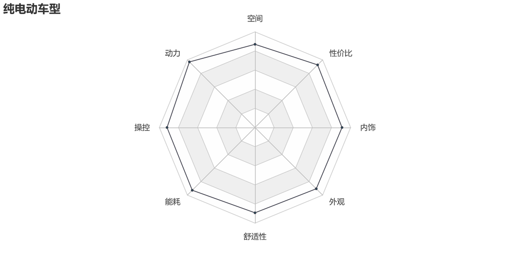

```python
v1.append([round(df_EV[i].mean(),2) for i in list_aspect])
radar = Radar("纯电动车型")
radar.config(schema)
radar.add("", v1, is_splitline=True, is_axisline_show=True,is_toolbox_show=False)
radar.render(path='纯电动车型雷达图.png')
Image.open('纯电动车型雷达图.png')
```

纯电动车型汽车各项评分表现较好，特别是动力评分。

7.4.2 插电式混合动力车型

```
phantomjs version: 2.1.1

Generating file ...
File saved in C:\Users\Administrator\Desktop\汽车之家\插电式混合动力车型雷达图.png
```

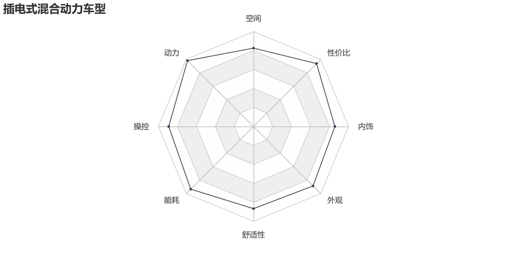

```python
v2.append([round(df_DM[i].mean(),2) for i in list_aspect])
radar = Radar("插电式混合动力车型")
radar.config(schema)
radar.add("", v2, is_splitline=True, is_axisline_show=True,is_toolbox_show=False)
radar.render(path='插电式混合动力车型雷达图.png')
Image.open('插电式混合动力车型雷达图.png')
```

插电式混合动力车型动力评分较高，而空间评分相比于其他方面较低。

7.4.3 各项对比

```
phantomjs version: 2.1.1

Generating file ...
File saved in C:\Users\Administrator\Desktop\汽车之家\各项对比.png
```

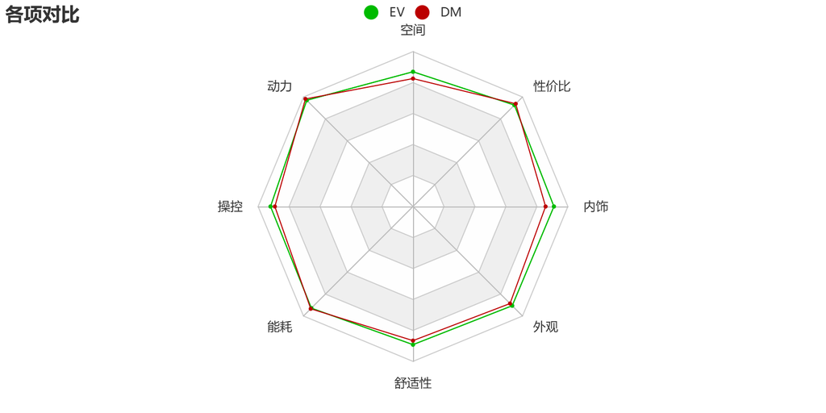

```python
radar = Radar("各项对比")
radar.config(schema)
radar.add("EV", v1, is_splitline=True,is_axisline_show=True,item_color='#00bb00')
radar.add("DM", v2, is_splitline=True,is_axisline_show=True,is_toolbox_show=False,item_color='#bb0000')
radar.render(path='各项对比.png')
Image.open('各项对比.png')
```

对比纯电动车型和插电式混合动力车型各方面评分，两种汽车类型各方面表现都较为良好。在性价比和动力方面两种汽车类型评分持平，但在其他方面纯电动车型略优于插电式混合动力车型；

8.购车目的

```python
#合并购车目的数据
df_purpose = df.购车目的1.append(df.购车目的2).append(df.购车目的3).append(df.购车目的4)
df_purpose.drop_duplicates()
df_purpose.value_counts()
```

```
上下班     1159
自驾游      672
购物       623
接送小孩     469
跑长途      141
泡妞        37
商务接送      36
赛车        23
拉货        11
越野         2
dtype: int64
```

```
phantomjs version: 2.1.1

Generating file ...
File saved in C:\Users\Administrator\Desktop\汽车之家\购车目的饼图.png
```

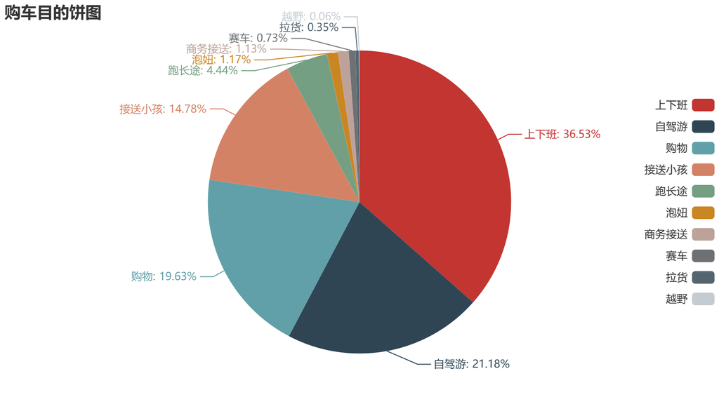

```python
pie = Pie("购车目的饼图",width = 800,height = 450)
pie.add("", df_purpose.value_counts().index,df_purpose.value_counts(),legend_orient='vertical',legend_pos='right',
        legend_top='center',is_toolbox_show=True,is_label_show=True)
pie.render('购车目的饼图.png')
Image.open('购车目的饼图.png')
```

9.口碑

9.1 总体口碑

```python
text_satisfy = ''
text_dissatisfy = ''
for i in range(len(df)):
    if df.最满意的一点.notna:
        text_satisfy = text_satisfy + str(df.loc[i,'最满意的一点'])
    if df.最不满意的一点.notna:
        text_dissatisfy = text_dissatisfy + str(df.loc[i,'最不满意的一点'])
```

```python
#创建停用词列表
stop_words = ['，','的','。','了','是',' ','我','也','很','满意','都','！','非常','最','有','在','好',
             '就','和','车','、','就是','比较','车子','可以','高','不','这款','秦','感觉','还是','还',
              '开','不错','而且','挺','nan','模式','没有','这','还有','跑','方面','时候','它','让',
              '起来','喜欢','特别','这个','公里','用','说','下','感','能','低','很多','上','到','现在',
              '一点','人','买','','；','一个','比亚迪','的话','没','功能','问题','比','大','吧','不够',
              '如果','不是','一些','觉得','有点','什么','但是','有些','会','小','太','后','明显','nannan',
              '过','多','一般','不好','对','去','不过','纯电','做','硬','那','地方','时','要','稍微','东西','再',
              '虽然','知道','差','不算','点','…','但','个','内','放','得',',','中','发现','情况','可能',
              '新车','真的','只能','·','）','（','被','容易','啊','那么','毕竟','来说','自己','确实','这车',
             '基本上','看起来','款','优势','这辆','给','纯','需要','其实','桩','有时候','平时','才','少',
              '所以','不能']
```

```python
#创建词云图函数
def word_cloud(word_text,p_path,topK = 10):
    tf_dic={}
    aspect=[]
    count_=[]
    word_list = [x for x in list(jieba.cut(word_text,cut_all = False)) if x not in stop_words]
    for w in word_list:
        tf_dic[w] = tf_dic.get(w,0)+1
    list_sorted = sorted(tf_dic.items(),key = lambda x:x[1],reverse=True)[:topK]
    for i,j in list_sorted:
        aspect.append(i)
        count_.append(j)
    wordcloud = WordCloud(p_path,width=750, height=500)
    wordcloud.add("", aspect,count_, word_size_range=[30, 100])
    wordcloud.render(p_path+".png")
    return Image.open(p_path+".png")
    #return wordcloud
```

9.1.1 最满意的一点(总体)

```
phantomjs version: 2.1.1

Generating file ...
File saved in C:\Users\Administrator\Desktop\汽车之家\最满意的一点(总体).png
```

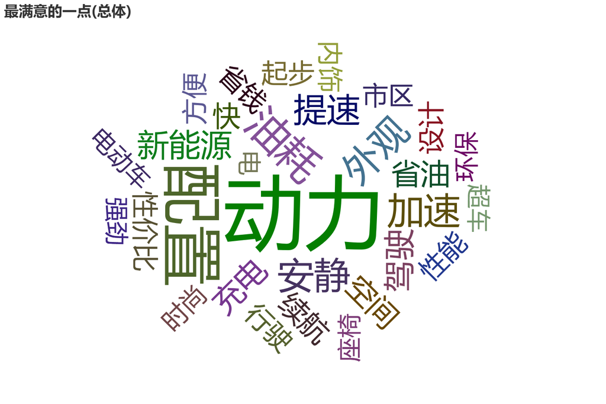

```python
word_cloud(text_satisfy,"最满意的一点(总体)",30)
```

总体上消费者对动力、配置、油耗、加速、外观等方面很满意。

9.1.1 最不满意的一点(总体)

```
phantomjs version: 2.1.1

Generating file ...
File saved in C:\Users\Administrator\Desktop\汽车之家\最不满意的一点(总体).png
```

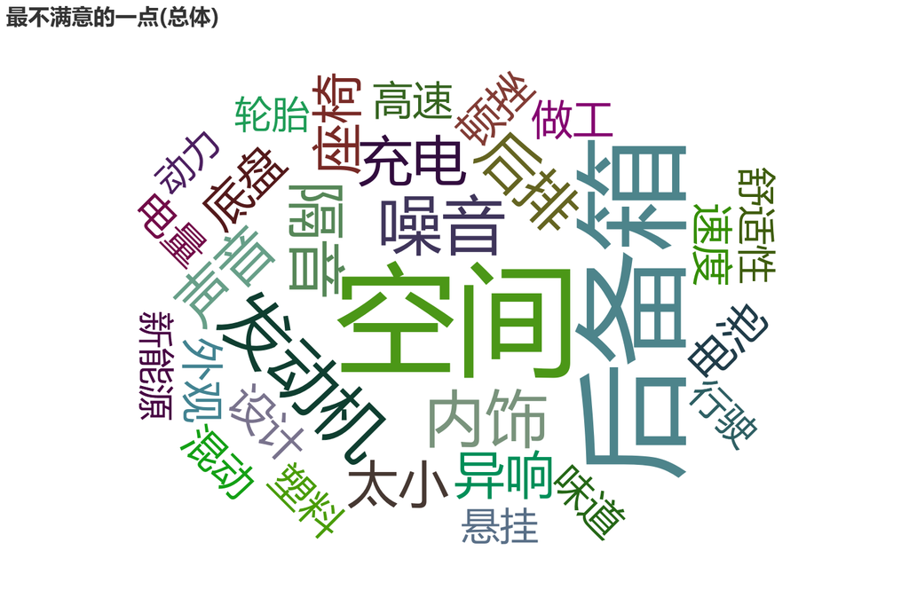

```python
word_cloud(text_dissatisfy,"最不满意的一点(总体)",30)
```

总体上消费者对空间、后备箱、发动机、内饰、噪音等方面表现出的不满意程度较高。需要在这些方面做出改进。

9.2 纯电动车型和插电式混合动力车型对比

```python
df_EV = df[df['汽车类型'] == 'EV'].reset_index(drop=True)
df_DM= df[df['汽车类型'] == 'DM'].reset_index(drop=True)

text_EV_satisfy = ''
text_DM_satisfy = ''
text_EV_dissatisfy = ''
text_DM_dissatisfy = ''

for i in range(len(df_EV)):
    if df.最满意的一点.notna:
        text_EV_satisfy = text_EV_satisfy + str(df_EV.loc[i,'最满意的一点'])
    if df.最不满意的一点.notna:
        text_EV_dissatisfy = text_EV_dissatisfy + str(df_EV.loc[i,'最不满意的一点'])
for i in range(len(df_DM)):
    if df.最满意的一点.notna:
        text_DM_satisfy = text_DM_satisfy + str(df_DM.loc[i,'最满意的一点'])
    if df.最不满意的一点.notna:
        text_DM_dissatisfy = text_DM_dissatisfy + str(df_DM.loc[i,'最不满意的一点'])
```

9.2.1 最满意的一点对比

9.2.1.1 最满意的一点对比(EV)

```
phantomjs version: 2.1.1

Generating file ...
File saved in C:\Users\Administrator\Desktop\汽车之家\最满意的一点(EV).png
```

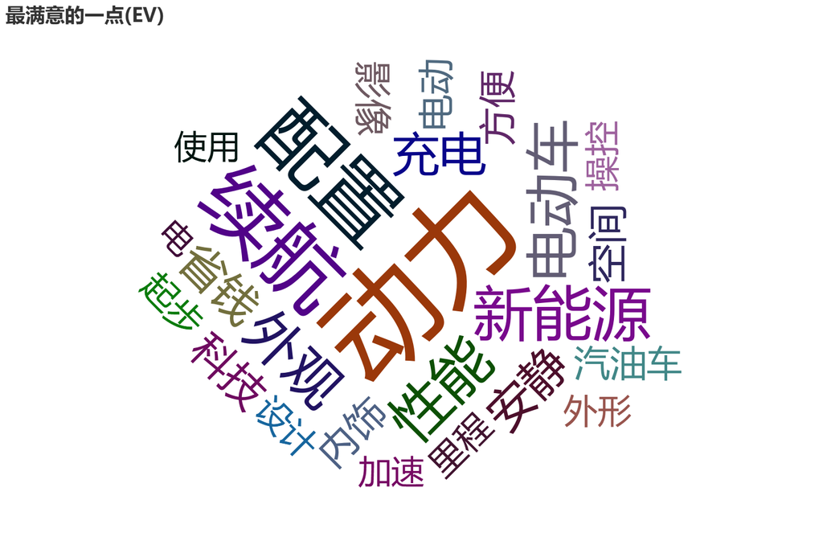

```python
word_cloud(text_EV_satisfy,"最满意的一点(EV)",25)
```

对于纯电动车型，消费者最满意的是动力、配置、续航、性能、新能源等方面。

9.2.1.2 最满意的一点对比(DM)

```
phantomjs version: 2.1.1

Generating file ...
File saved in C:\Users\Administrator\Desktop\汽车之家\最满意的一点(DM).png
```

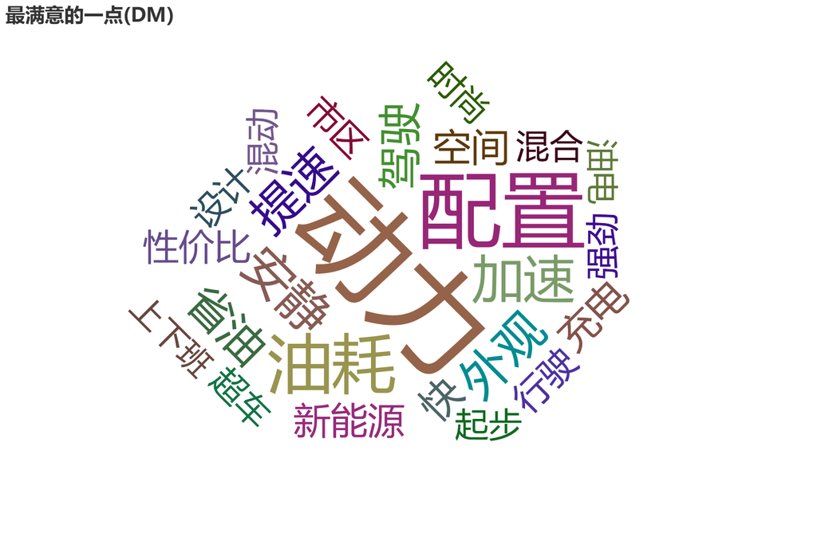

```python
word_cloud(text_DM_satisfy,"最满意的一点(DM)",25)
```

对于插电式混合动力车型，消费者最满意的是动力、配置、外观、油耗、加速等方面。

9.2.2 最不满意的一点对比

9.2.2.1 最不满意的一点对比(EV)

```
phantomjs version: 2.1.1

Generating file ...
File saved in C:\Users\Administrator\Desktop\汽车之家\最不满意的一点(EV).png
```

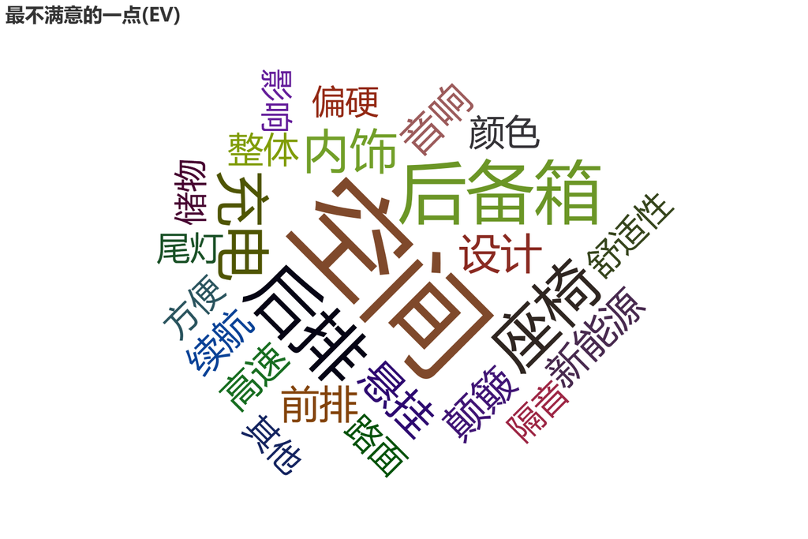

```python
word_cloud(text_EV_dissatisfy,"最不满意的一点(EV)",25)
```

对于纯电动车型，消费者最不满意的是空间、后排、后备箱、座椅、充电等方面，需要在这些方面加以改进。

9.2.2.2 最不满意的一点对比(DM)

```
phantomjs version: 2.1.1

Generating file ...
File saved in C:\Users\Administrator\Desktop\汽车之家\最不满意的一点(DM).png
```

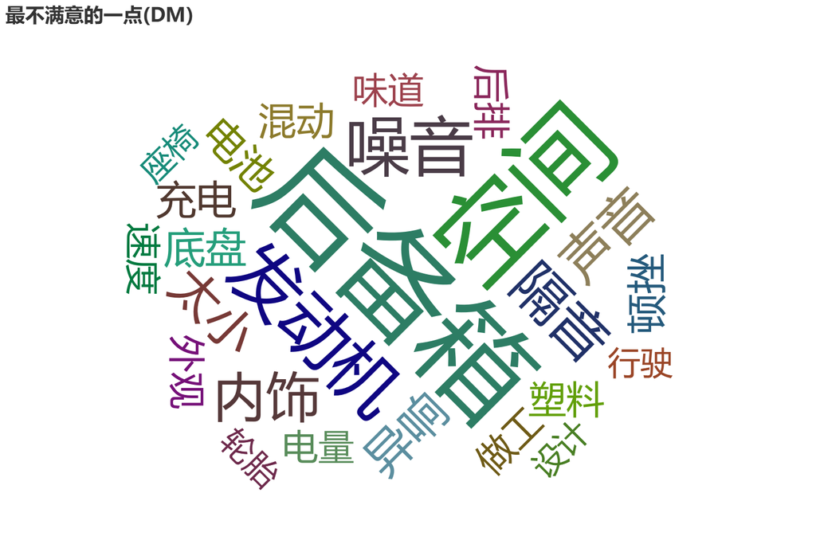

```python
word_cloud(text_DM_dissatisfy,"最不满意的一点(DM)",25)
```

对于插电式混合动力车型，消费者最不满意的是后备箱、空间、发动机、噪音、内饰等方面，需要在这些方面加以改进。

## 总结

### 所有车型

#### 总体数据

- 此口碑数据集中数量最多的车型为 2015款 1.5T 双冠旗舰Plus版
- 平均售价最高的车型为 2016款 秦EV300 旗舰型
- 购买地点数量前三的城市为上海、深圳和北京
- 车辆的购买时间自2014年至2017年逐年递减，可能是由于口碑评价的滞后性，导致越早期的车有着更多的口碑评价，应该关注这个问题分析其他原因并促进消费者进行口碑评价的积极性以提高数据的时效性

#### 各项评分

- 综合评分最高的车型为 2016款 秦EV300 豪华型
- 各车型空间评分差距略明显，其中2017款 1.5T 秦100 拥有最高的空间评分4.74分，而2014款 1.5T酷黑骑士尊贵型的空间评分仅为3.45分；各车型动力方面评分较高，操控性能、舒适性、内饰评分随着车型的更迭呈现上升趋势；性价比评分前三的车型为 2014 款1.5T 酷黑骑士尊贵型，2018款 秦EV450 智联锋尚型和2016款秦EV300豪华型

#### 口碑

- 总体上消费者对动力、配置、油耗、加速、外观等方面很满意
- 总体上消费者对空间、后备箱、发动机、内饰、噪音等方面表现出的不满意程度较高。需要在这些方面做出改进

### 纯电动车型和插电式混合动力车型对比

#### 总体数据

- 此口碑数据集包含插电式混合动力车型的数量为988辆，纯电动车型为242辆
- 纯电动车型平均售价为19.7万元，插电式混合动力车型平均售价为15.9万元，纯电动车型价格更高一些

#### 各项评分

- 纯电动车型综合评分为4.58分，插电式混合车型综合评分为4.49分，纯电动车型综合评分略高
- 对比纯电动车型和插电式混合动力车型各方面评分，两种汽车类型各方面表现都较为良好。在性价比和动力方面两种汽车类型评分持平，但在其他方面纯电动车型略优于插电式混合动力车型

#### 口碑

最满意的一点

- 对于纯电动车型，消费者最满意的是动力、配置、续航、性能、新能源等方面
- 对于插电式混合动力车型，消费者最满意的是动力、配置、外观、油耗、加速等方面

最不满意的一点

- 对于纯电动车型，消费者最不满意的主要是空间、后排、后备箱、座椅、充电等方面，需要在这些方面加以改进
- 对于插电式混合动力车型，消费者最不满意的主要是后备箱、空间、发动机、噪音、内饰等方面，需要在这些方面加以改进

## 不足与规划

### 不足

- 此口碑数据集数据量较少
- 口碑数据信息存在滞后性，主要数据是已上市很久车型的数据

### 规划

- 促进车主及时进行口碑评价
- 主动向车主进行调研获取数据
- 后续分析中可以加入竞品车型进行对比分析，寻找出存在的优势与不足，找到新的竞争点